# Test 2, STAT 245 for pwv6

STAT 245 Fall 2024

## Response variable

Fit a regression model using as your response variable: whether a faculty member felt “pushed” from their academic job.

## Data Access

You can find your data at: https://sldr.netlify.app/data/faculty-retention2.csv

## Context

This dataset was recently analyzed by Katie Spoon and colleagues in the paper [*Gender and retention patterns among U.S. faculty*](https://www.science.org/doi/10.1126/sciadv.adi2205).

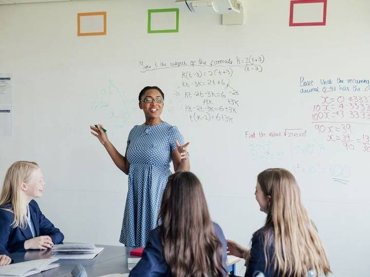

Image from merriam-webster.com

The researchers state,

> > Women remain underrepresented among faculty in nearly all academic fields. Using a census of 245,270 tenure-track and tenured professors at United States–based PhD-granting departments, we show that women leave academia overall at higher rates than men at every career age, in large part because of strongly gendered attrition at lower-prestige institutions, in non-STEM fields, and among tenured faculty. A large-scale survey of the same faculty indicates that the reasons faculty leave are gendered, even for institutions, fields, and career ages in which retention rates are not. Women are more likely than men to feel pushed from their jobs and less likely to feel pulled toward better opportunities, and women leave or consider leaving because of workplace climate more often than work-life balance. These results quantify the systemic nature of gendered faculty retention; contextualize its relationship with career age, institutional prestige, and field; and highlight the importance of understanding the gendered reasons for attrition rather than focusing on rates alone.

Can you replicate some of their results in your analysis?

Variables in the data set include:

- `group`: whether the people in this group are “current” faculty members, ones who “left” academia, “retired,” or “switched” jobs within academia.
- `gender` of the people in this group
- `years_since_phd`: number of years since finishing a PhD degree (categorical)
- `prestige_decile`: Integer. Institutions have a unique prestige ranking that has been binned into deciles 1-10 for privacy, where 10 is the most prestigious decile and 1 is the least prestigious.
- `STEM`: Either “STEM”, “Non-STEM”, or NA. Whether the faculty members work in STEM or other fields. A small amount of faculty whose primary appointments encompass STEM and Non-STEM fields are marked as NA.
- `subgroup_total`: Integer. Total number of people in the given [group, gender, age_group, prestige_decile, STEM] subgroup.
- `pushed`: Number of people who said they would or did leave their jobs because something “pushed” them out (a reason they wanted to leave; not a better place to go). `not_pushed` is `subgroup_total` minus `pushed`, and `prop_pushed` is `pushed` / `subgroup_total`.
- `pulled`: Number of people who said they would or did leave their jobs because something “pulled” them out (a better new opportunity, not a problem with their existing position). `not_pulled` is `subgroup_total` minus `pulled`, and `prop_pulled` is `pulled` / `subgroup_total`.
- `prof_major_impact`: Number of people who said professional reasons would or did have a “major impact” on their decisions to leave their job. `not_prof_major_impact` is `subgroup_total` minus `prof_major_impact`, and `prop_prof` is `prof_major_impact` / `subgroup_total`.
- `balance_major_impact`: Number of people who said work-life balance reasons would or did have a “major impact” on their decisions to leave their job. `not_balance_major_impact` is `subgroup_total` minus `balance_major_impact`, and `prop_balance` is `balance_major_impact` / `subgroup_total`.
- `climate_major_impact`: Number of people who said workplace climate reasons would or did have a “major impact” on their decisions to leave their job. `not_climate_major_impact` is `subgroup_total` minus `climate_major_impact`, and `prop_climate` is `climate_major_impact` / `subgroup_total`.